# Taxes

October 15, 2018

## Why a tax?

- To fund group investments:
  - roads
  - schools
  - defense
  - health care
  - parks
  - research
- To encourage or discourage behavior.

## Not always an effective behavior deterrent…

[video not shown]

## Types of taxes

Taxes can be levied on almost anything:

- Income
- Property
- Capital gains
- Estate
- Transportation
- Imports
- Etc…

  “In this world, nothing can be said to be certain except death and taxes.” - Benjamin Franklin

## Sales taxes

- **Excise tax** - A tax on the sale of a good or service. It is usually composed of a local and state component.

[Washington DOR Sales Tax Schedule](https://dor.wa.gov/get-form-or-publication/forms-subject/local-sales-use-tax-rates-citycounty)

(A similar form exists for property taxes.)

## Impact of a sales tax

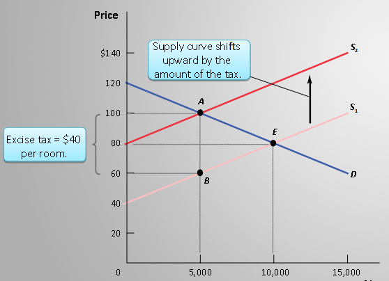

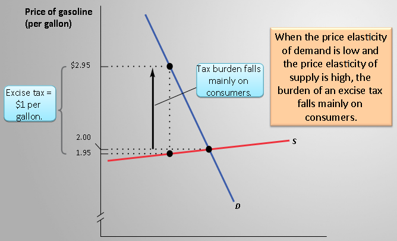

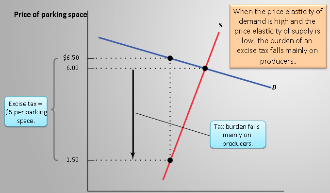

## Taxes can be…

- **Progressive tax** - A tax that **increases** the percentage paid as income increases.
- **Regressive tax** - A tax that **decreases** the percentage paid as income increases.
- **Proportional tax** - A tax that is the **same** percentage of income regardless of income level.

Income tax in particular can be progressive ([Source](https://taxfoundation.org/2018-tax-brackets/)):

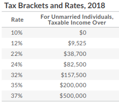

## Why U.S. income taxes are so difficult to file

[Adam Ruins Everything on taxes](http://videos.criticalcommons.org/transcoded/http/www.criticalcommons.org/Members/jtierney86/clips/adam-ruins-everything-rent-seeking/video_file/mp4-high/rent-seeking-mp4.mp4?_=1)

## Subsidies / Tax Breaks

- A subsidy is a negative tax in which the government gives money.

Examples: Farm subsidies, corporate subsidies

## Subsidies / Tax Breaks: Competition over companies

Cities often compete to incentivize a company to move there by giving significant tax breaks. Often the cost of these tax breaks is higher than the benefit of the company.

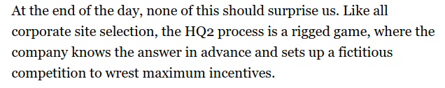

[Source](https://www.citylab.com/equity/2018/05/the-hypocrisy-of-amazons-hq2-process/560072/)

## Subsidies / Tax Breaks: Support for low-income families

- The earned income tax credit (EITC) is a negative income tax for families with low incomes ($6000 - $15000 for no children, $10000-$40000 for one child).
- An interesting proposal much discussed globally is the **Universal Basic Income** (UBI), in which all residents receive a subsidy, regardless of their income.

## Universal Basic Income

[video not shown]

## Wrapping Up

- Complete the [knowledge check](https://goo.gl/forms/KvwFW0Ocin5JwJIZ2) for today’s participation point.
- Please provide [feedback](https://goo.gl/forms/8SiOwdi19kN8cINJ3) on today’s lecture.